# Homework 1: Vectors Solutions

## Problem 1: Vector Operations

The following vectors are given:
$$\mathbf{a}= \begin{bmatrix} 3 \\ -1 \\ 2 \end{bmatrix}, \qquad \mathbf{b}=\begin{bmatrix} 2 \\ 4 \\ -5 \end{bmatrix}, \qquad \mathbf{c} = \begin{bmatrix} 5 \\ 6.5 \\ -7 \end{bmatrix}$$

Find the values of:

1. $\mathbf{a}+\mathbf{b}$
2. $\mathbf{a}+\mathbf{b}-\mathbf{c}$
3. $\mathbf{a}^T+\mathbf{b}^T-\mathbf{c}^T$
4. $3\mathbf{a}^T+4\mathbf{b}^T-2\mathbf{c}^T$
5. $6\mathbf{a}^T+8\mathbf{b}^T-4\mathbf{c}^T$
6. $\mathbf{a} \cdot \mathbf{b}$
7. $(3\mathbf{a} - 6\mathbf{b}) \cdot \mathbf{c}$
8. $\mathbf{a} \cdot (4\mathbf{a}^T - \mathbf{b}^T)^T$

### Solutions

1. $\mathbf{a}+\mathbf{b} = \begin{bmatrix} 3 \\ -1 \\ 2 \end{bmatrix} + \begin{bmatrix} 2 \\ 4 \\ -5 \end{bmatrix} = \begin{bmatrix} 5 \\ 3 \\ -3 \end{bmatrix}$
2. $\mathbf{a}+\mathbf{b}-\mathbf{c} = \begin{bmatrix} 5 \\ 3 \\ -3 \end{bmatrix} - \begin{bmatrix} 5 \\ 6.5 \\ -7 \end{bmatrix} = \begin{bmatrix} 0 \\ -3.5 \\ 4 \end{bmatrix}$
3. $\mathbf{a}^T+\mathbf{b}^T-\mathbf{c}^T = [3 \quad -1 \quad 2] + [2 \quad 4 \quad -5] - [5 \quad 6.5 \quad -7] = [0 \quad -3.5 \quad 4]$
4. $3\mathbf{a}^T+4\mathbf{b}^T-2\mathbf{c}^T = 3[3 \quad -1 \quad 2] + 4[2 \quad 4 \quad -5] - 2[5 \quad 6.5 \quad -7]$ $= [9 \quad -3 \quad 6] + [8 \quad 16 \quad -20] - [10 \quad 13 \quad -14] = [7 \quad 0 \quad 0]$
5. $6\mathbf{a}^T+8\mathbf{b}^T-4\mathbf{c}^T = 2(3\mathbf{a}^T+4\mathbf{b}^T-2\mathbf{c}^T) = 2[7 \quad 0 \quad 0] = [14 \quad 0 \quad 0]$
6. $\mathbf{a} \cdot \mathbf{b} = \begin{bmatrix} 3 \\ -1 \\ 2 \end{bmatrix} \cdot \begin{bmatrix} 2 \\ 4 \\ -5 \end{bmatrix} = 3(2) + (-1)(4) + 2(-5) = 6 - 4 - 10 = -8$
7. $(3\mathbf{a} - 6\mathbf{b}) \cdot \mathbf{c} = \left(3\begin{bmatrix} 3 \\ -1 \\ 2 \end{bmatrix} - 6\begin{bmatrix} 2 \\ 4 \\ -5 \end{bmatrix}\right) \cdot \begin{bmatrix} 5 \\ 6.5 \\ -7 \end{bmatrix}$ $= \left(\begin{bmatrix} 9 \\ -3 \\ 6 \end{bmatrix} - \begin{bmatrix} 12 \\ 24 \\ -30 \end{bmatrix}\right) \cdot \begin{bmatrix} 5 \\ 6.5 \\ -7 \end{bmatrix} = \begin{bmatrix} -3 \\ -27 \\ 36 \end{bmatrix} \cdot \begin{bmatrix} 5 \\ 6.5 \\ -7 \end{bmatrix}$ $= (-3)(5) + (-27)(6.5) + (36)(-7) = -15 - 175.5 - 252 = -442.5$
8. $\mathbf{a} \cdot (4\mathbf{a}^T - \mathbf{b}^T)^T = \mathbf{a} \cdot (4\mathbf{a} - \mathbf{b})$ $= \begin{bmatrix} 3 \\ -1 \\ 2 \end{bmatrix} \cdot \left(4\begin{bmatrix} 3 \\ -1 \\ 2 \end{bmatrix} - \begin{bmatrix} 2 \\ 4 \\ -5 \end{bmatrix}\right)$ $= \begin{bmatrix} 3 \\ -1 \\ 2 \end{bmatrix} \cdot \begin{bmatrix} 10 \\ -8 \\ 13 \end{bmatrix} = 3(10) + (-1)(-8) + 2(13) = 30 + 8 + 26 = 64$

## Problem 2: Translation Office

A translation office translated $\mathbf{a}=[24, 17, 9, 13]$ documents from English, French, German and Russian, respectively. For each of those languages, it takes about $\mathbf{b}=[5, 10, 11, 7]$ minutes to translate one page.

How much time did they spend translating in total? How much did each of the translators spend on average if there are $4$ translators in the office? Write an expression for this amount in terms of the vectors $\mathbf{a}$ and $\mathbf{b}$.

### Solution

**Total time spent:** The total time is the dot product of vectors $\mathbf{a}$ and $\mathbf{b}$:
$$\text{Total Time} = \mathbf{a} \cdot \mathbf{b} = [24, 17, 9, 13] \cdot [5, 10, 11, 7]$$
$$= 24(5) + 17(10) + 9(11) + 13(7) = 120 + 170 + 99 + 91 = 480 \text{ minutes}$$

**Average time per translator:** With 4 translators, each translator works on average:
$$\text{Average Time} = \frac{\mathbf{a} \cdot \mathbf{b}}{4} = \frac{480}{4} = 120 \text{ minutes}$$

**Expression in terms of vectors:** - Total time: $\mathbf{a} \cdot \mathbf{b}$ - Average time per translator: $\frac{\mathbf{a} \cdot \mathbf{b}}{4}$

## Problem 3: Vector Norms

Calculate the Manhattan (L1) and Euclidean (L2) norms of the following vectors:

1. $\mathbf{a}= \begin{bmatrix} 2\\-9\\3 \end{bmatrix}$
2. $\mathbf{a}-2\mathbf{b}$, where $\mathbf{a}= \begin{bmatrix}3\\4\\1\\0\end{bmatrix},\ \mathbf{b} = \begin{bmatrix}4\\5\\-2\\-1\end{bmatrix}$
3. $-3\mathbf{c}$, where $\mathbf{c}= \begin{bmatrix}2\\-5\\6\end{bmatrix}$

### Solutions

1. For $\mathbf{a}= \begin{bmatrix} 2\\-9\\3 \end{bmatrix}$:
   - Manhattan norm (L1): $\|\mathbf{a}\|_1 = |2| + |-9| + |3| = 2 + 9 + 3 = 14$
   - Euclidean norm (L2): $\|\mathbf{a}\|_2 = \sqrt{2^2 + (-9)^2 + 3^2} = \sqrt{4 + 81 + 9} = \sqrt{94}$
2. First compute $\mathbf{a}-2\mathbf{b}$: $\mathbf{a}-2\mathbf{b} = \begin{bmatrix}3\\4\\1\\0\end{bmatrix} - 2\begin{bmatrix}4\\5\\-2\\-1\end{bmatrix} = \begin{bmatrix}3\\4\\1\\0\end{bmatrix} - \begin{bmatrix}8\\10\\-4\\-2\end{bmatrix} = \begin{bmatrix}-5\\-6\\5\\2\end{bmatrix}$
   - Manhattan norm: $\|\mathbf{a}-2\mathbf{b}\|_1 = |-5| + |-6| + |5| + |2| = 5 + 6 + 5 + 2 = 18$
   - Euclidean norm: $\|\mathbf{a}-2\mathbf{b}\|_2 = \sqrt{(-5)^2 + (-6)^2 + 5^2 + 2^2} = \sqrt{25 + 36 + 25 + 4} = \sqrt{90} = 3\sqrt{10}$
3. For $-3\mathbf{c}$ where $\mathbf{c}= \begin{bmatrix}2\\-5\\6\end{bmatrix}$: $-3\mathbf{c} = \begin{bmatrix}-6\\15\\-18\end{bmatrix}$
   - Manhattan norm: $\|-3\mathbf{c}\|_1 = |-6| + |15| + |-18| = 6 + 15 + 18 = 39$
   - Euclidean norm: $\|-3\mathbf{c}\|_2 = \sqrt{(-6)^2 + 15^2 + (-18)^2} = \sqrt{36 + 225 + 324} = \sqrt{585} = 3\sqrt{65}$

**Note:** For any scalar $k$ and vector $\mathbf{v}$: $\|k\mathbf{v}\| = |k|\|\mathbf{v}\|$

## Problem 4: Angles Between Vectors

Find the angles between the following vectors:

1. $\mathbf{a}= \begin{bmatrix} 2\\1\\1\end{bmatrix}$ and $\mathbf{b}= \begin{bmatrix} 1\\-3\\3\end{bmatrix}$
2. The vectors $\mathbf{a}$ from Problem 3a) and $\mathbf{c}$ from Problem 3c)

## Problem 5: Matrix-Vector Multiplication

What vectors do you get by applying the matrix
$$A = \begin{bmatrix} 3 & -3 \\ 3 & 3 \end{bmatrix}$$
on the vectors:

1. $\mathbf{a}=\begin{bmatrix} 1 \\ 0 \end{bmatrix}$
2. $\mathbf{b}=\begin{bmatrix} 0 \\ 1 \end{bmatrix}$
3. $\mathbf{c}=\begin{bmatrix} 1 \\ 1 \end{bmatrix}$

(Additional:) Draw the vectors before and after multiplying with $A$. What can you say visually about the matrix? Can you guess how it will act on the vector $[2\,\,\,\,\,\,\,\, -2]$?

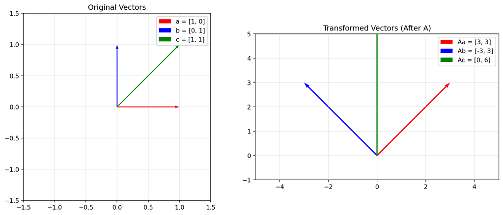

Figure 1: Matrix Transformation Visualization

### Solutions

1. $A\mathbf{a} = \begin{bmatrix} 3 & -3 \\ 3 & 3 \end{bmatrix}\begin{bmatrix} 1 \\ 0 \end{bmatrix} = \begin{bmatrix} 3(1) + (-3)(0) \\ 3(1) + 3(0) \end{bmatrix} = \begin{bmatrix} 3 \\ 3 \end{bmatrix}$
2. $A\mathbf{b} = \begin{bmatrix} 3 & -3 \\ 3 & 3 \end{bmatrix}\begin{bmatrix} 0 \\ 1 \end{bmatrix} = \begin{bmatrix} 3(0) + (-3)(1) \\ 3(0) + 3(1) \end{bmatrix} = \begin{bmatrix} -3 \\ 3 \end{bmatrix}$
3. $A\mathbf{c} = \begin{bmatrix} 3 & -3 \\ 3 & 3 \end{bmatrix}\begin{bmatrix} 1 \\ 1 \end{bmatrix} = \begin{bmatrix} 3(1) + (-3)(1) \\ 3(1) + 3(1) \end{bmatrix} = \begin{bmatrix} 0 \\ 6 \end{bmatrix}$

**Visual Analysis:** Looking at the transformation, we can see that: - The matrix $A$ rotates and scales vectors - It appears to combine rotation and scaling - The determinant is $\det(A) = 3(3) - (-3)(3) = 9 + 9 = 18$, indicating a scaling factor

**Prediction for $[2, -2]$:** $A\begin{bmatrix} 2 \\ -2 \end{bmatrix} = \begin{bmatrix} 3 & -3 \\ 3 & 3 \end{bmatrix}\begin{bmatrix} 2 \\ -2 \end{bmatrix} = \begin{bmatrix} 6 + 6 \\ 6 - 6 \end{bmatrix} = \begin{bmatrix} 12 \\ 0 \end{bmatrix}$

## Problem 6: Matrix Products

Compute the following products:

1. $AB$, where $A=\begin{bmatrix} 6&5\\-2&7 \end{bmatrix}$, $B=\begin{bmatrix} -5&3\\1&4 \end{bmatrix}$
2. $(A-B)(A+B)$, where $A=\begin{bmatrix} 2&2&4\\-3&-2&4\\-2&0&2 \end{bmatrix}$, $B=\begin{bmatrix} 2&1&3\\-1&2&2\\1&4&-1 \end{bmatrix}$
3. $A^2 - B^2$, with the same $A$ and $B$ as in b)

### Solutions

1. $AB = \begin{bmatrix} 6&5\\-2&7 \end{bmatrix}\begin{bmatrix} -5&3\\1&4 \end{bmatrix}$ $= \begin{bmatrix} 6(-5)+5(1) & 6(3)+5(4) \\ -2(-5)+7(1) & -2(3)+7(4) \end{bmatrix} = \begin{bmatrix} -25 & 38 \\ 17 & 22 \end{bmatrix}$
2. First compute $A-B$ and $A+B$: $A-B = \begin{bmatrix} 0&1&1\\-2&-4&2\\-3&-4&3 \end{bmatrix}$, $A+B = \begin{bmatrix} 4&3&7\\-4&0&6\\-1&4&1 \end{bmatrix}$

**Note:** $(A-B)(A+B) \neq A^2 - B^2$ in general because matrix multiplication is not commutative!

## Problem 7: Shear Matrix (Additional)

Consider the following matrix (called the *shear matrix*):
$$S = \begin{bmatrix} 1 & 1 \\ 0 & 1 \end{bmatrix}$$

1. What would you get if you apply $S$ on the vector $[0 \quad 1]$?
2. What would you get if you apply $S$ again on the result of the previous point?
3. What if you apply $S$ one more time?
4. What do you think happens when we apply $S$ 100 times on that vector?
5. Can you compute $S^{100}$?

### Solutions

1. $S\begin{bmatrix} 0 \\ 1 \end{bmatrix} = \begin{bmatrix} 1 & 1 \\ 0 & 1 \end{bmatrix}\begin{bmatrix} 0 \\ 1 \end{bmatrix} = \begin{bmatrix} 1 \\ 1 \end{bmatrix}$
2. $S^2\begin{bmatrix} 0 \\ 1 \end{bmatrix} = S\begin{bmatrix} 1 \\ 1 \end{bmatrix} = \begin{bmatrix} 2 \\ 1 \end{bmatrix}$
3. $S^3\begin{bmatrix} 0 \\ 1 \end{bmatrix} = S\begin{bmatrix} 2 \\ 1 \end{bmatrix} = \begin{bmatrix} 3 \\ 1 \end{bmatrix}$
4. **Pattern recognition:** We can see that $S^n\begin{bmatrix} 0 \\ 1 \end{bmatrix} = \begin{bmatrix} n \\ 1 \end{bmatrix}$

   Therefore: $S^{100}\begin{bmatrix} 0 \\ 1 \end{bmatrix} = \begin{bmatrix} 100 \\ 1 \end{bmatrix}$
5. **Computing $S^{100}$:** Let’s find the pattern for $S^n$:
   - $S^1 = \begin{bmatrix} 1 & 1 \\ 0 & 1 \end{bmatrix}$
   - $S^2 = \begin{bmatrix} 1 & 2 \\ 0 & 1 \end{bmatrix}$
   - $S^3 = \begin{bmatrix} 1 & 3 \\ 0 & 1 \end{bmatrix}$

   **General pattern:** $S^n = \begin{bmatrix} 1 & n \\ 0 & 1 \end{bmatrix}$

   Therefore: $S^{100} = \begin{bmatrix} 1 & 100 \\ 0 & 1 \end{bmatrix}$

**Verification:** This can be proven by induction or by noting that $S = I + N$ where $N = \begin{bmatrix} 0 & 1 \\ 0 & 0 \end{bmatrix}$ is nilpotent ($N^2 = 0$).

## Problem 8: Vector Spaces (Additional)

Show that the following set is a vector space:

1. $A = \left\{ \begin{bmatrix} a \\ 0 \end{bmatrix} \mid \text{ for all numbers }a\in\mathbb{R}\right\}$
2. $B = \left\{ \begin{bmatrix} a \\ -a \end{bmatrix} \mid \text{ for all numbers }a\in\mathbb{R}\right\}$

### Solutions

To show these are vector spaces, we need to verify the 8 axioms. We’ll show the key ones:

**For set A:** $A = \left\{ \begin{bmatrix} a \\ 0 \end{bmatrix} \mid a\in\mathbb{R}\right\}$

1. **Closure under addition:** If $\mathbf{u} = \begin{bmatrix} a \\ 0 \end{bmatrix}$ and $\mathbf{v} = \begin{bmatrix} b \\ 0 \end{bmatrix}$ are in $A$, then $\mathbf{u} + \mathbf{v} = \begin{bmatrix} a+b \\ 0 \end{bmatrix} \in A$ ✓
2. **Closure under scalar multiplication:** If $\mathbf{u} = \begin{bmatrix} a \\ 0 \end{bmatrix} \in A$ and $c \in \mathbb{R}$, then $c\mathbf{u} = \begin{bmatrix} ca \\ 0 \end{bmatrix} \in A$ ✓
3. **Zero vector:** $\mathbf{0} = \begin{bmatrix} 0 \\ 0 \end{bmatrix} \in A$ ✓
4. **Additive inverse:** For $\mathbf{u} = \begin{bmatrix} a \\ 0 \end{bmatrix}$, we have $-\mathbf{u} = \begin{bmatrix} -a \\ 0 \end{bmatrix} \in A$ ✓

**For set B:** $B = \left\{ \begin{bmatrix} a \\ -a \end{bmatrix} \mid a\in\mathbb{R}\right\}$

1. **Closure under addition:** If $\mathbf{u} = \begin{bmatrix} a \\ -a \end{bmatrix}$ and $\mathbf{v} = \begin{bmatrix} b \\ -b \end{bmatrix}$ are in $B$, then $\mathbf{u} + \mathbf{v} = \begin{bmatrix} a+b \\ -(a+b) \end{bmatrix} \in B$ ✓
2. **Closure under scalar multiplication:** If $\mathbf{u} = \begin{bmatrix} a \\ -a \end{bmatrix} \in B$ and $c \in \mathbb{R}$, then $c\mathbf{u} = \begin{bmatrix} ca \\ -ca \end{bmatrix} \in B$ ✓
3. **Zero vector:** $\mathbf{0} = \begin{bmatrix} 0 \\ 0 \end{bmatrix} \in B$ ✓
4. **Additive inverse:** For $\mathbf{u} = \begin{bmatrix} a \\ -a \end{bmatrix}$, we have $-\mathbf{u} = \begin{bmatrix} -a \\ a \end{bmatrix} \in B$ ✓

Both sets satisfy all vector space axioms, so they are vector spaces.

## Problem 9: Non-Vector Spaces (Additional)

Show that the following set is *not* a vector space:

1. $A = \mathbb{N}$ (natural numbers)
2. $B = \left\{ \begin{bmatrix} a \\ 1 \end{bmatrix} \mid \text{ for all numbers }a\in\mathbb{R}\right\}$

### Solutions

To show these are NOT vector spaces, we need to find axioms that fail:

1. **$A = \mathbb{N}$ (natural numbers):**

   **Failure of zero vector:** A vector space must contain a zero vector $\mathbf{0}$ such that $\mathbf{v} + \mathbf{0} = \mathbf{v}$ for all $\mathbf{v}$.

   But $0 \notin \mathbb{N}$ (natural numbers are $\{1, 2, 3, ...\}$), so there’s no zero element.

   **Alternative failure:** Closure under addition fails because natural numbers can grow arbitrarily large, but this doesn’t directly violate vector space axioms in the traditional sense.
2. **$B = \left\{ \begin{bmatrix} a \\ 1 \end{bmatrix} \mid a\in\mathbb{R}\right\}$:**

   **Failure of zero vector:** For a vector space, we need $\mathbf{0} = \begin{bmatrix} 0 \\ 0 \end{bmatrix}$.

   But $\begin{bmatrix} 0 \\ 0 \end{bmatrix} \notin B$ because the second component must be 1, not 0.

   **Alternative failure - closure under addition:** Take $\mathbf{u} = \begin{bmatrix} 1 \\ 1 \end{bmatrix}$ and $\mathbf{v} = \begin{bmatrix} 2 \\ 1 \end{bmatrix}$, both in $B$.

   Then $\mathbf{u} + \mathbf{v} = \begin{bmatrix} 3 \\ 2 \end{bmatrix} \notin B$ because the second component is 2, not 1.

Both sets fail to be vector spaces due to fundamental structural requirements.